# The Affect of Living or Not Living with Guardians on Student Independence

Project 2

490294583, 480438353, 480188609, 490404001 | Friday 8am Carslaw Computational Lab 610/611 N.James

University of Sydney | DATA1001 | APRIL 2019

# 1 Executive Summary

The following report provides an analysis of survey data collected from university students in an attempt to determine whether students who move away from their parents/guardians have increased independence, are more organised and have a better work ethic (especially in relation to their studies). The data was obtained from 10 survey questions answered by 81 mostly USYD students, with most answers having to be rough estimates. Overall, the data did not prove any correlation between moving away from home and students having greater independence and organisation in relation to university work. Whilst in some areas there were differences between the two groups, mostly there was no distinction between students living with their parents/guardians and those on their own. This conclusion was supported by our first two research questions, which examined how much time students spent at university/studying and how organised and well planned their study regime was. Overall there was very little difference in these areas, and whilst the second research question suggested that students living on their own are more likely to plan their day/week, there was not enough evidence to draw significant conclusions. We then performed a linear regression of percentage of lectures attended and percentage of campus Wi-Fi used for study, but due to the lack of correlation found it would not be useful for making predictions.

# 2 Initial Data Analysis

.

```r
library(ggplot2)
setwd("C:/Users/Lewis/Docs/DATA1001files/Data")
survey = read.csv("survey.csv")
gender = survey$What.is.your.gender.
age = survey$What.is.your.age.
sleep = survey$On.average..what.time.do.you.go.to.sleep.
guardianslive = survey$Do.you.live.with.your.parents.guardians.
guardianswork = survey$How.often.do.your.parents.guardians.ask.about.and.or.pester.you.to.do.university.work.
lectures = survey$What.percentage.of.lectures.do.you.attend.in.person..e.g..75..
wifi = survey$When.using.campus.internet..what.percentage.of.your.time.is.spent.on.university.work...i.e..not.recreational..e.g..75..
study = survey$On.average..how.many.hours.do.you.spend.studying.per.day...e.g..4.hours.
plan = survey$How.do.you.plan.your.day.week.
work = survey$Do.you.have.a.job...including.part.time..casual..etc.
```

Showing the dimensions

```r
dim(survey)
```

```
## [1] 81 11
```

Showing the structure

```r
str(survey)
```

```
## 'data.frame':    81 obs. of  11 variables:
##  $ Timestamp                                                                                                              : Factor w/ 63 levels "","4/09/2019 18:04",..: 2 3 3 4 5 6 7 7 7 8 ...
##  $ What.is.your.gender.                                                                                                   : Factor w/ 3 levels "Female","Male",..: 2 1 2 1 2 1 2 2 2 2 ...
##  $ What.is.your.age.                                                                                                      : int  18 24 18 18 17 18 19 18 18 18 ...
##  $ On.average..what.time.do.you.go.to.sleep.                                                                              : Factor w/ 29 levels "0:00:00","0:30:00",..: 19 27 1 1 4 28 23 19 27 7 ...
##  $ Do.you.live.with.your.parents.guardians.                                                                               : Factor w/ 2 levels "No","Yes": 2 1 2 1 2 2 2 1 2 2 ...
##  $ How.often.do.your.parents.guardians.ask.about.and.or.pester.you.to.do.university.work.                                 : Factor w/ 5 levels "Never","Often",..: 4 2 5 4 1 2 1 5 1 4 ...
##  $ What.percentage.of.lectures.do.you.attend.in.person..e.g..75..                                                         : int  95 75 100 50 75 90 80 0 100 90 ...
##  $ When.using.campus.internet..what.percentage.of.your.time.is.spent.on.university.work...i.e..not.recreational..e.g..75..: int  80 100 70 75 50 60 70 20 90 80 ...
##  $ On.average..how.many.hours.do.you.spend.studying.per.day...e.g..4.hours.                                               : num  4 4.5 3 3 4 3 2 0 4 4 ...
##  $ How.do.you.plan.your.day.week.                                                                                         : Factor w/ 3 levels "Extensively",..: 3 1 3 3 3 2 3 2 2 3 ...
##  $ Do.you.have.a.job...including.part.time..casual..etc.                                                                  : Factor w/ 2 levels "No","Yes": 2 2 2 2 1 2 1 1 1 1 ...
```

## 2.1 Purpose

The purpose of creating the survey was to determine whether students moving away from their parents/guardians increases their independence, work ethic and organization, especially in relation to their university work. Living on your own for the first time presents challenges as it requires you to engage in processes for the first time “without parental guidance and intervention.(Downing, 2012) However, according to studies most students respond well and”moving away from home appears to have a significant positive impact upon the development of metacognition in undergraduates.“(Downing, 2012) With this survey we attempted to find evidence of this phenomena amongst university students in Sydney, with the study mainly focusing on the University of Sydney but also encapsulating the University of New South Wales and the University of Technology Sydney.

## 2.2 Stakeholders

Among the stakeholders for this survey would be individuals and groups who take an interest in how students adapt to living independently (on campus or off). This includes the universities and other individuals responsible for creating the learning environment that these students will spend their time in. Knowing more about how students react to living on their own will enable them to more effectively facilitate their time at university. Parents will also naturally be interested in how their children develop once they leave home, as will students about to move to attend university.

## 2.3 Survey Design

The survey was administered as a Google Form in order for it to be easily shared and answered. The survey questions were written to provide data on various aspects of students’ lives that we believed would be good indicators of work ethic and independence. None of the questions in the survey are very personally intrusive and thus the participants can be expected to answer to the best of their ability. We also used inclusive language within the survey to allow for fair responses to the survey. One issue with the data we collected is that responses to some questions would be estimates, some of which are for questions relating to long periods of time, such as percentage of lectures attended, and thus are unlikely to be completely accurate. One limitation of asking for an estimated percentage is that respondents would be inclined to round their answer to a tidy number which would hinder the ability to perform regression analysis. In addition the two groups of students were of different sizes however we accounted for this by using proportions for some graphs. A potential bias is that most of the participants in the survey are from the University of Sydney, which is obviously not reflective of all university students in Australia. However, the survey does include students from the University of New South Wales and UTS, which addresses that issue to a certain extent. Similarly, although there were 81 respondents to the survey, this sample size could always be bigger in order to provide a better representation of the population of students.

# 3 Research Question 1

## 3.1 Does living with your parents/guardians affect how much time you spend at university/studying?

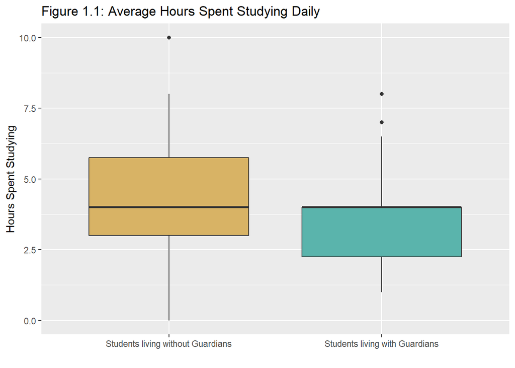

```r
f11 = ggplot(data = survey, aes(x = guardianslive, y = study))
f11 + geom_boxplot(fill = c('#d8b365','#5ab4ac')) + ggtitle("Figure 1.1: Average Hours Spent Studying Daily") + xlab("") + ylab("Hours Spent Studying") + scale_x_discrete(labels = c('Students living without Guardians','Students living with Guardians'))
```

Summary of Study hours where students do not live with guardians

```r
summary(study[which(guardianslive=="No")])
```

```
##    Min. 1st Qu.  Median    Mean 3rd Qu.    Max.
##   0.000   3.000   4.000   4.413   5.750  10.000
```

Summary of Study hours where students live with guardians

```r
summary(study[which(guardianslive=="Yes")])
```

```
##    Min. 1st Qu.  Median    Mean 3rd Qu.    Max.
##   1.000   2.250   4.000   3.614   4.000   8.000
```

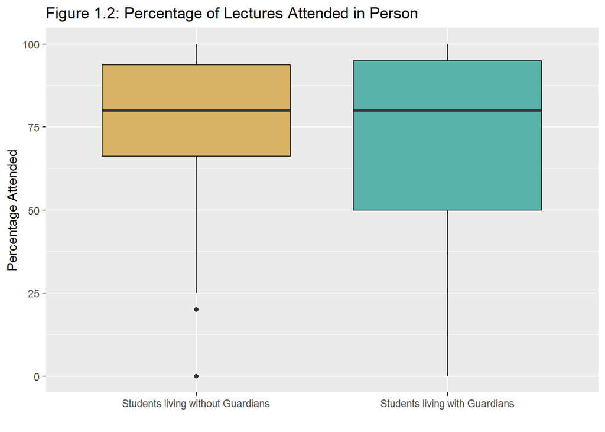

```r
f12 = ggplot(data = survey, aes(x = guardianslive, y =lectures))
f12 + geom_boxplot(fill = c('#d8b365','#5ab4ac')) + ggtitle("Figure 1.2: Percentage of Lectures Attended in Person") + xlab("") + ylab("Percentage Attended") + scale_x_discrete(labels = c('Students living without Guardians','Students living with Guardians'))
```

```r
summary(study[which(guardianslive=="No")])
```

```
##    Min. 1st Qu.  Median    Mean 3rd Qu.    Max.
##   0.000   3.000   4.000   4.413   5.750  10.000
```

```r
summary(study[which(guardianslive=="Yes")])
```

```
##    Min. 1st Qu.  Median    Mean 3rd Qu.    Max.
##   1.000   2.250   4.000   3.614   4.000   8.000
```

In order to examine this research question we looked specifically at two questions from the survey: how many hours were spent studying per day (on average) and what percentage of lectures were attended in person. By examining these questions we hoped to get a better idea both of how closely students followed the curriculum and how much independent effort they put into their studies. The data gathered for the 2 questions is communicated in Figures 1.1 and 1.2, both of which demonstrate no significant difference between students who live at home and those who don’t. The median for both groups of students for both studies was almost exactly the same, those medians being the students attending 80% of their lectures in person and studying for about 4 hours a day. The median was thought to be a better metric for comparing the two groups as its greater robustness meant it was not as affected by the significant outliers of our dataset as much as the mean, as well as being more appropriate for skewed data. The variation of the two groups also does not provide any distinguishing features as students living at home have greater variation for one question and less for the other. Thus there is no clear difference between the groups for either box plot and we can conclude that living on your own or with a parent/guardian has no effect on the amount of time spent studying or attending lectures, and thus in this case does not have any effect on the diligence and work ethic of university students.

# 4 Research Question 2

## 4.1 Does living with your parents/guardians affect how organised and well planned your study regime is?

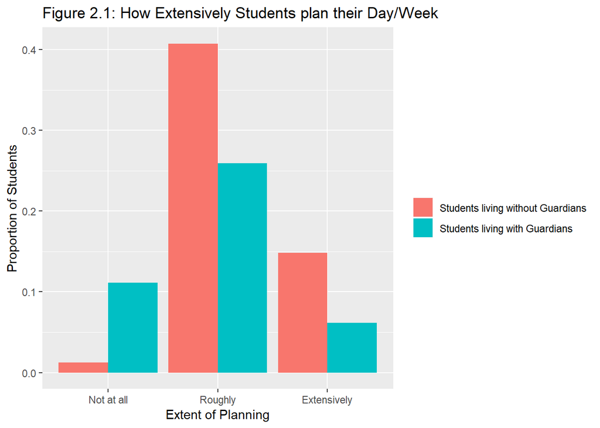

```r
plan = factor(plan, levels = c("Not at all", "Roughly", "Extensively"))
guardianswork = factor(guardianswork, levels = c("Never", "Rarely", "Sometimes", "Often", "Perpetually"))

f21 = ggplot(survey, aes(x = plan,fill = guardianslive))
f21 + ylab('Proportion of Students') + xlab('Extent of Planning') + geom_bar(position = 'dodge',aes(y = (..count..)/sum(..count..))) + ggtitle('Figure 2.1: How Extensively Students plan their Day/Week') + scale_fill_discrete(name = '',labels = c('Students living without Guardians','Students living with Guardians'))
```

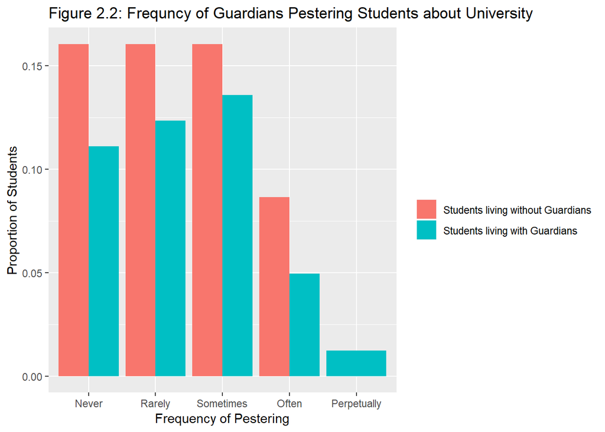

```r
f22 = ggplot(survey, aes(x = guardianswork,fill = guardianslive))
f22 + ylab('Proportion of Students') + xlab("Frequency of Pestering") + geom_bar(position = 'dodge',aes(y = (..count..)/sum(..count..))) + ggtitle("Figure 2.2: Frequncy of Guardians Pestering Students about University") + scale_fill_discrete(name = '',labels = c('Students living without Guardians','Students living with Guardians'))
```

For this research question, two factors from the students’ routine were examined: how extensively do they plan their day/week and how often do their parents ask about/or pester them to do university work. In terms of the former the data shown in figure 2.1 demonstrates that if a student does not live with their parents/guardians they are more likely to plan out their day/week more extensively. More than 97% of the students who don’t live with their parents/guardians plan out their day/week at least roughly, whilst the figure for students who live at home is 74%. Obviously the difference is not huge but does nevertheless suggest that students living away from home are more organised in terms of planning their studies and other activities. The other area study we examined (how often parents pester them) does not suggest any difference between the two groups of students. There are similar results for each qualitative category in Figure 2.2, thus suggesting that there is no difference in how independent and self-reliant students are in their approach to their studies, with parents feeling the need to remind them about assignments and such whether they live on their own or not. Therefore we can conclude that whilst there is some evidence of correlation between students living on their own and how organised/self reliant they are (in terms of studies) for the first area of study, there is none for the second. Thus there is not enough evidence to state with any certainty that living on your own affects how organised and well planned your study regime is.

# 5 Research Question 3

### 5.0.1 Correlation and Linear Regression for Figure 3.1:

```r
plot(wifi[which(guardianslive=="Yes")], lectures[which(guardianslive=="Yes")], main = "Figure 3.1: Wifi vs Lecutres Students living with Guardians" , xlab = "Percentage of Wifi Usage for Academic Purposes", ylab = "Percentage of Lectures Attended")
cor(wifi[which(guardianslive=="Yes")], lectures[which(guardianslive=="Yes")])
```

```
## [1] -0.01919174
```

```r
Lyesw = lm(lectures[which(guardianslive=="Yes")]~wifi[which(guardianslive=="Yes")])
Lyesw$coefficients
```

```
##                         (Intercept) wifi[which(guardianslive == "Yes")]
##                         73.68256200                         -0.03189721
```

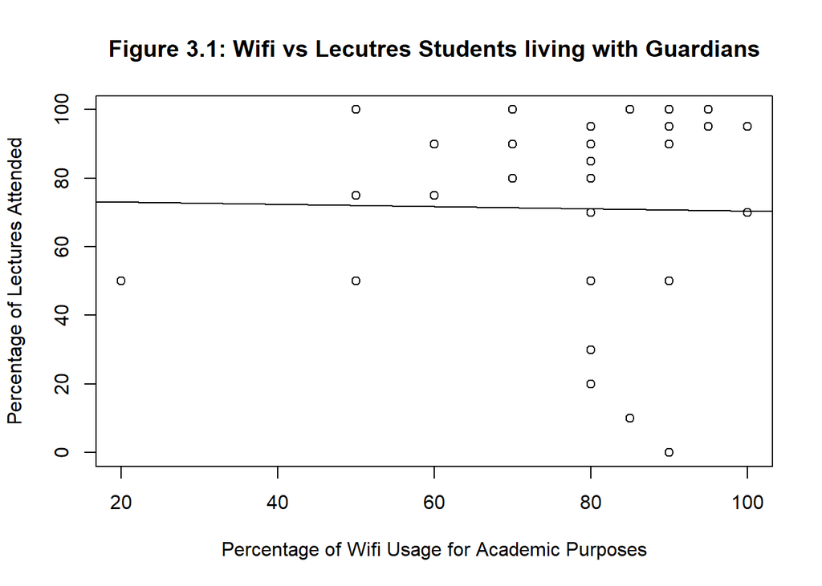

```r
abline(a=73.68256200, b=-0.03189721)
```

Figure 3.1 shows the relationship between academic wifi usage on campus and lecture attendance for students who live with their guardians. The plot along with the correlation coefficient of -0.01919174 demonstrates that there is not a linear relationship between these two variables in the case of students who live with their guardians. Although a linear regression line can be produced, due to the lack of correlation it is not an appropriate model to apply and it cannot be used to make useful predictions.

### 5.0.2 Correlation and Linear Regression for Figure 3.2:

```r
plot(wifi[which(guardianslive=="No")], lectures[which(guardianslive=="No")], main = "Figure 3.2: Wifi vs Lecutres Students not living with Guardians" , xlab = "Percentage of Wifi Usage for Academic Purposes", ylab = "Percentage of Lectures Attended")
cor(wifi[which(guardianslive=="No")], lectures[which(guardianslive=="No")])
```

```
## [1] 0.3120808
```

```r
Lnow = lm(lectures[which(guardianslive=="No")]~wifi[which(guardianslive=="No")])
Lnow$coefficients
```

```
##                        (Intercept) wifi[which(guardianslive == "No")]
##                         48.2584687                          0.3600925
```

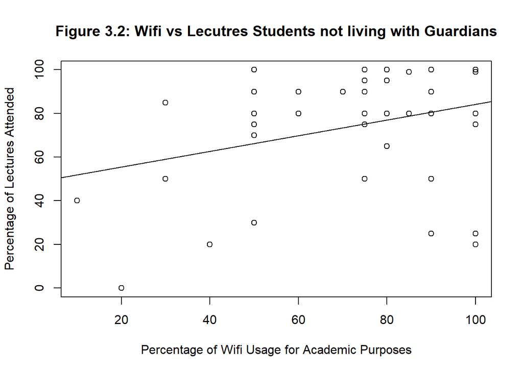

```r
abline(a= 48.2584687, b= 0.3600925)
```

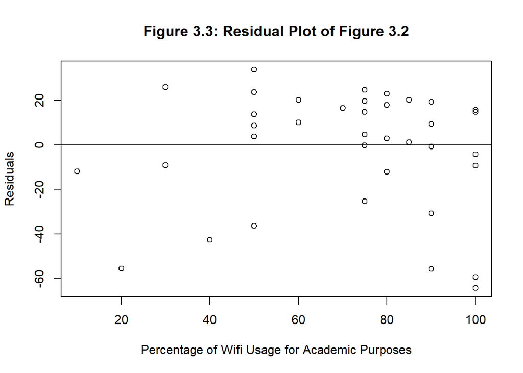

```r
plot(wifi[which(guardianslive=="No")], Lnow$residuals, main = "Figure 3.3: Residual Plot of Figure 3.2", ylab="Residuals", xlab = "Percentage of Wifi Usage for Academic Purposes")
abline(h=0)
```

Similarly, the residual plot Figure 3.3 shows that the model is over-predicting by up to 60% for some values, hence predictions cannot accurately be made. An issue with applying linear regression in both these cases is that as percentages were used to gather data for these survey questions, the data is bounded between 0% and 100% yet the model is not. Regressions that may be a better fit are beta regression and logistic regression as these deal with variables that are bounded. From these figures it can be seen that for both groups of students that campus wifi usage cannot be used to accurately predict the percentages of lectures a student attends.

# 6 References and Link to Survey

## 6.1 Link to Survey

https://docs.google.com/forms/d/e/1FAIpQLSfYfO3lP2Y9DqiNh1m6Tu_6ThKASd0hF0WKf0Wa-23_DLKLGg/viewform

## 6.2 References

Downing, K. (2012). The Impact of Moving Away from Home on Undergraduate Metacognitive Development. Current Topics in Childrens Learning and Cognition. doi:10.5772/47944